# Oneil Cruz Pitch Sequencing

### Series against Baltimore (August 5th - 7th)

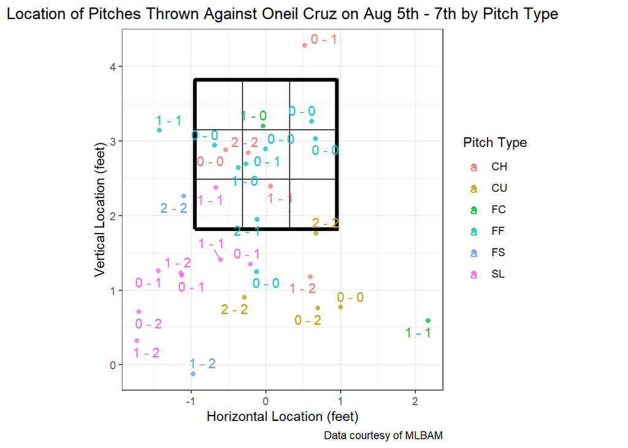

On at-bats when Oneil Cruz struck out, pitchers threw him eight sliders (~27% of pitches). Seven out of eight of them were below the zone. Three of those eight sliders were on two strike counts, which he subsequently struck out on. Three of them were on 0 - 1 counts, the second pitch of the at-bat. The other two were on 1 - 1 counts. In this series, pitchers were throwing Cruz sliders to the opposite side of the plate as him and below the zone. Additionally, five out of the eight were not on two strike counts.

### Sliders in at-bats ending in strikeouts over the whole season

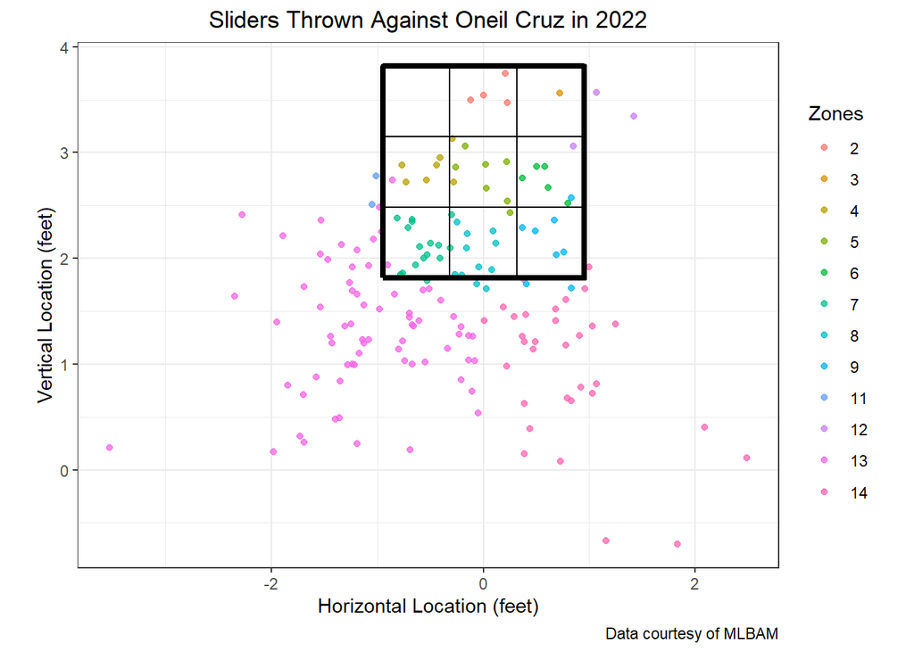

There appears to be a trend of sliders being thrown below, to the left (catcher’s perspective), and in the bottom third of the zone when considering all sliders thrown against Oneil Cruz in ABs ending in a strikeout. Those locations are hardest for Oneil Cruz to hit as a left-handed hitter. After looking at a couple of at-bats and general location of sliders against Oneil Cruz, we begin to look deeper.

# What pitches did Cruz face this season?

We’re going to look at the number of different types of pitches Cruz faced this season. Then, we’re going to compare what he was thrown against other left-handed hitters.

## Types of pitches thrown against Oneil Cruz in 2022

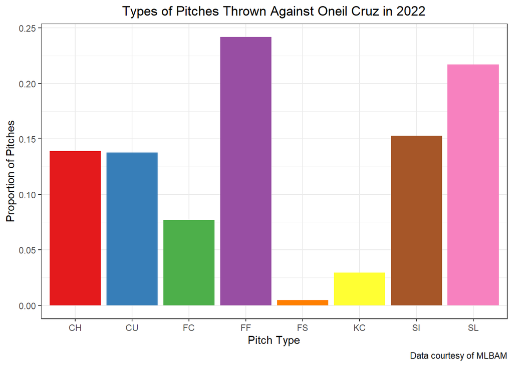

24.2% of pitches Cruz saw in 2022 were 4-seam fastballs. The second most pitches he saw were sliders at 21.7%. How does that compare to other left-handed hitters?

## Compared to ALL left-handed hitters

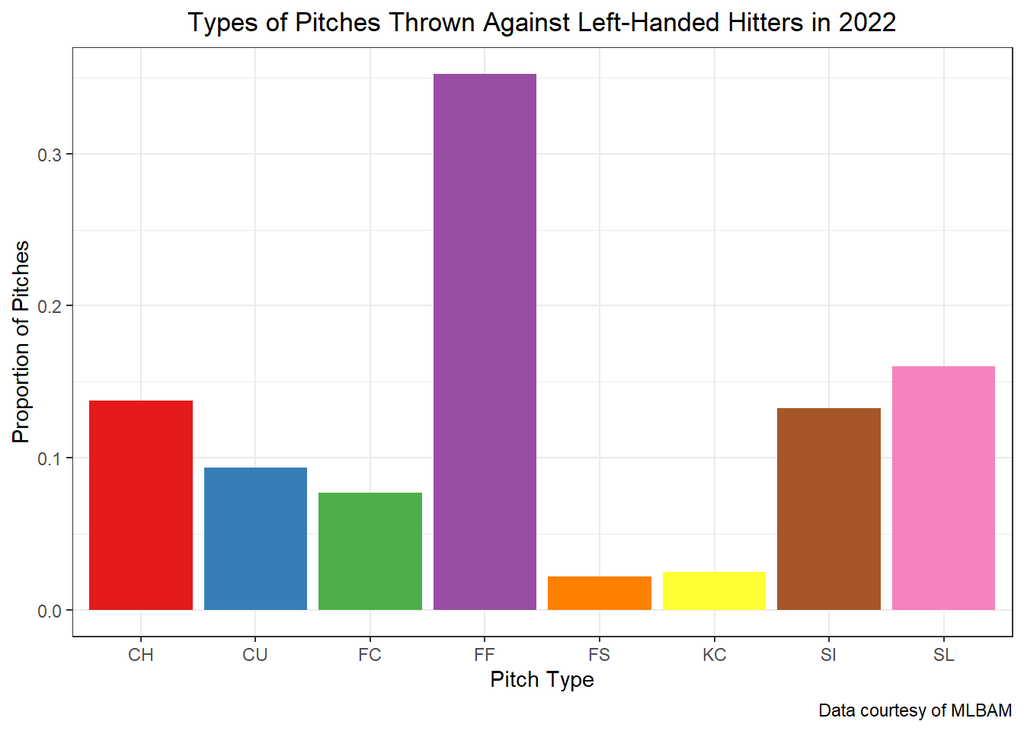

Other left-handed batters are seeing sliders at the second highest clip as well; however, the number is approximately 16%, almost 6% lower than Oneil Cruz’s rate of sliders. Additionally, Cruz sees more than 10% less 4-seam fastballs than other lefties. He is seeing an above average amount of sliders compared to other left-handed batters. Pitchers are throwing a lot of sliders Cruz’s way.

# Strikeout Data

Next, we’re looking at the number of pitches Cruz strikes out against and comparing that to other left-handed batters.

## Number of strikeouts by each pitch

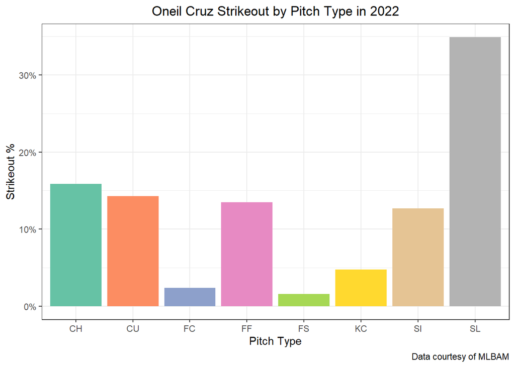

Oneil Cruz struck out 126 times last year. The pitch that he struck out the most on was slider (44 times or 35%), which is twice as much as the second most struck out pitch, the changeup (20 times or ~16%).

## Strikeout pitches compared to other left-handed batters

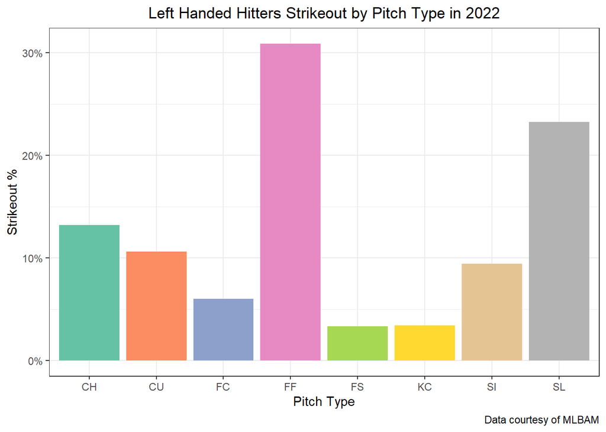

Other left handed batters’ biggest strikeout pitch is the 4-seam fastball, the cause of over 30% of strikeouts. Oneil Cruz struck out on 4-seam fastballs less than 15% of the time, which is less than half of what other lefties were doing. The slider was the second biggest strikeout pitch against left-handed hitters at a rate of approximately 24%, which is over 11% lower than Cruz’s rate against sliders.